# Class 13: Trees and Forests

## Decision Trees

Today we will start by looking at a new dataset of housing prices in Ames, Iowa. Unlike our other housing dataset though, the samples here are of individual houses.

```r
ames <- read_csv("https://statsmaths.github.com/ml_data/ames.csv")
ames
```

```
## # A tibble: 2,678 x 76
##    obs_id train_id saleprice ms_subclass ms_zoning lot_area street
##    <chr>  <chr>        <dbl> <chr>       <chr>        <dbl> <chr>
##  1 id_00… train       215000 020         RL           31770 Pave
##  2 id_00… train       105000 020         RH           11622 Pave
##  3 id_00… train       172000 020         RL           14267 Pave
##  4 id_00… test            NA 020         RL           11160 Pave
##  5 id_00… train       189900 060         RL           13830 Pave
##  6 id_00… test            NA 060         RL            9978 Pave
##  7 id_00… test            NA 120         RL            4920 Pave
##  8 id_00… valid       191500 120         RL            5005 Pave
##  9 id_00… valid       236500 120         RL            5389 Pave
## 10 id_00… train       189000 060         RL            7500 Pave
## # … with 2,668 more rows, and 69 more variables: lot_shape <chr>,
## #   land_contour <chr>, utilities <chr>, lot_config <chr>,
## #   land_slope <chr>, neighborhood <chr>, condition_1 <chr>,
## #   condition_2 <chr>, bldg_type <chr>, house_style <chr>,
## #   overall_qual <dbl>, overall_cond <dbl>, year_built <dbl>,
## #   `year_remod/add` <dbl>, roof_style <chr>, roof_matl <chr>,
## #   exterior_1st <chr>, exterior_2nd <chr>, mas_vnr_type <chr>,
## #   mas_vnr_area <dbl>, exter_qual <chr>, exter_cond <chr>,
## #   foundation <chr>, bsmt_qual <chr>, bsmt_cond <chr>,
## #   bsmt_exposure <chr>, bsmtfin_type_1 <chr>, bsmtfin_sf_1 <dbl>,
## #   bsmtfin_type_2 <chr>, bsmtfin_sf_2 <dbl>, bsmt_unf_sf <dbl>,
## #   total_bsmt_sf <dbl>, heating <chr>, heating_qc <chr>,
## #   central_air <chr>, electrical <chr>, `1st_flr_sf` <dbl>,
## #   `2nd_flr_sf` <dbl>, low_qual_fin_sf <dbl>, gr_liv_area <dbl>,
## #   bsmt_full_bath <dbl>, bsmt_half_bath <dbl>, full_bath <dbl>,
## #   half_bath <dbl>, bedroom_abvgr <dbl>, kitchen_abvgr <dbl>,
## #   kitchen_qual <chr>, totrms_abvgrd <dbl>, functional <chr>,
## #   fireplaces <dbl>, garage_type <chr>, garage_yr_blt <dbl>,
## #   garage_finish <chr>, garage_cars <dbl>, garage_area <dbl>,
## #   garage_qual <chr>, garage_cond <chr>, paved_drive <chr>,
## #   wood_deck_sf <dbl>, open_porch_sf <dbl>, enclosed_porch <dbl>,
## #   `3ssn_porch` <dbl>, screen_porch <dbl>, pool_area <dbl>,
## #   misc_val <dbl>, mo_sold <dbl>, yr_sold <dbl>, sale_type <chr>,
## #   sale_condition <chr>
```

One way to build a predictive algorithm is to create a decision tree. The best way to understand what this is is to see an example. Here, we use the `tree` library to predict sales price:

```r
library(tree)
model <- tree(saleprice ~ neighborhood + overall_qual + overall_cond + year_built,
                      data = ames, subset = train_id == "train",
              control = tree.control(nobs = nrow(ames), mindev = 0.005))
```

This relatively old library needs a special plotting notation (so don’t worry if this looks strange)

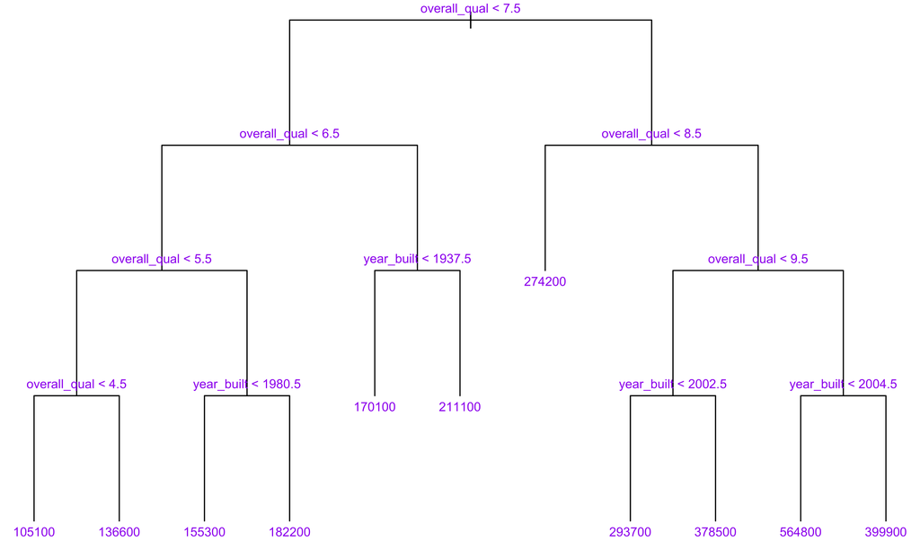

```r
par(mar = c(0,0,0,0))
plot(model, type = "uniform")
text(model, cex = 0.7, col = "purple")
```

In order to do prediction, we start at the top of the tree and look at each logical statement. If True, move to the left and if False move to right. At the bottom (the *terminal nodes* or *leaves*), there are predicted values. The tree was built by greedily picking variables to spit the dataset up by until some stopping criterion was reached; this is usually a fixed depth, a fixed proportion of the data, or a fixed decrease in the RMSE of accuracy rate.

## Random Forests

Decision trees give very noisy predictions due to their use of greedy logic and because points on the boundary of a decision cut-off are forced into a fixed bucket. By noisy, I mean that a slightly different training set would yield significantly different predictions for at least some of the test points. This may seem like a design flaw, but we can easily turn it into a design feature!

The idea of a random forest is to add some randomness into the decision tree algorithm, fit a large number of trees using this random variation, and produce predictions by averaging together the predictions from all these individual trees (its a *forest* because there are a lot of trees; get it?). The random logic applies only to the building of the trees; once created, each tree is exactly the same as in the case above. The randomness comes from two sources:

- for each tree, select only a subset of the training data to train with;
- for each split, select only a subset of the available variables to split on.

The exact values for these two random features can be set as hyperparameters. We can fit random forests using the `randomForest` function from the package with the same name as follows:

```r
library(randomForest)
set.seed(1)
model <- randomForest(saleprice ~ overall_qual + year_built,
                      data = ames, subset = train_id == "train",
                      ntree = 20, maxnodes = 3, mtry = 1)
```

Here I selected 20 randomly generated trees, each having at most 3 terminal nodes and only allowing one variable to be used at each split. These are very low settings, used only for illustrating the algorithm here. We can get predictions from each individual tree by setting `predict.all` to `TRUE`:

```r
obj <- predict(model, newdata = ames, predict.all = TRUE)$individual
```

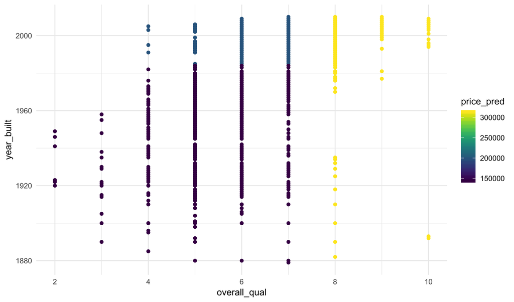

```r
mutate(ames, price_pred = obj[,4]) %>%
  ggplot(aes(overall_qual, year_built)) +
    geom_point(aes(color = price_pred)) +
    viridis::scale_color_viridis()
```

Can you figure out roughly what the tree looks like? It first splits on overall quality being less than 7.5, and then splits the lower quality houses by year built around 1982. The individual prediction is not very smooth or complex.

Taking all of the twenty trees together, the average model looks quite a bit different:

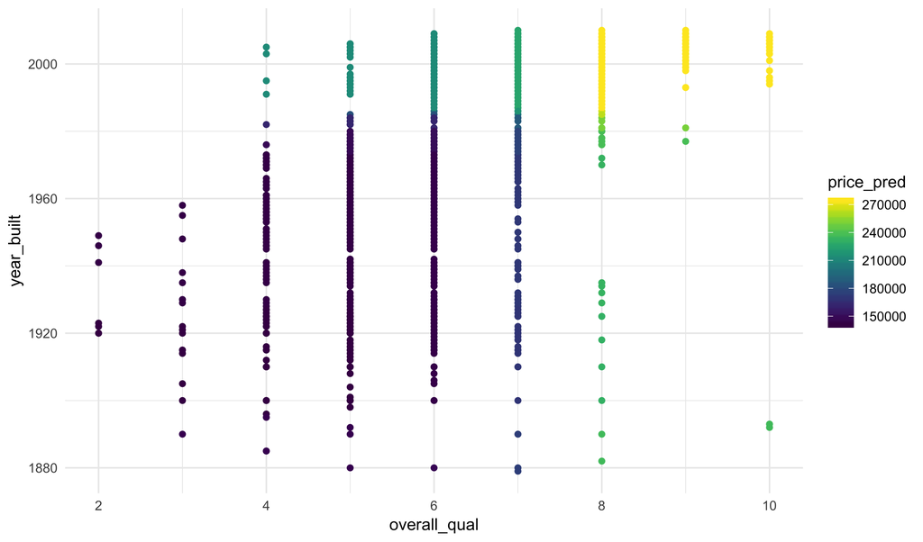

```r
mutate(ames, price_pred = predict(model, newdata = ames)) %>%
  ggplot(aes(overall_qual, year_built)) +
    geom_point(aes(color = price_pred)) +
    viridis::scale_color_viridis()
```

Helpfully, the **randomForest** also provides the function `importance` that measures how important each variable is to the model.

```r
importance(model)
```

```
##              IncNodePurity
## overall_qual  2.553334e+12
## year_built    2.234421e+12
```

This is a measurement of how often the variable was used in the model and how much it decreased the RMSE each time it was used to split the dataset.

## Gradient Boosted Trees

Gradient boosted trees offer a slightly different approach to random forests for making use of the noisy nature of decision trees. Like random forests, they construct a number of trees, each using only a subset of the training data. They do not restrict the variables available for each node to split on. Most importantly, gradient boosted trees are fit in a sequence, with each tree trying to predict the residuals left over by the other trees.

More precisely, if the fitted values from the t-th tree are given by:

$$\widehat{Y_i^{(t)}}$$

Then we train the k-th tree on the values Z given by:

$$Z_i = Y_i - \eta \cdot \sum_{t = 1}^{k - 1} \widehat{Y_i^{(t)}}$$

The parameter eta is the learning rate. If set to one, this is exactly fitting on the residuals of the prior trees. Setting to less than one stop the trees from overfitting from the first few trees. Here, we prepare a larger set of variables from the `ames` dataset:

```r
X <- model.matrix(~ . -1 , data = ames[,-c(1:3)])
y <- ames$saleprice

y_train <- y[ames$train_id == "train"]
y_valid <- y[ames$train_id == "valid"]
X_train <- X[ames$train_id == "train",]
X_valid <- X[ames$train_id == "valid",]
```

```r
library(xgboost)
model <- xgboost(data = X_train, label = y_train,
                 max_depth = 2, eta = 0.01, nthread = 2,
                 nrounds = 10, objective = "reg:linear",
                 verbose = 1)
```

And we can do prediction on the dataset:

```r
y_pred <- predict(model, newdata = X)
sqrt(tapply((y - y_pred)^2, ames$train_id, mean))
```

```
##     test    train    valid
##       NA 184367.7 184145.2
```

Alternatively, we can use the function `xgb.DMatrix` to combine the data matrix and labels:

```r
data_train <- xgb.DMatrix(data = X_train, label = y_train)
data_valid <- xgb.DMatrix(data = X_valid, label = y_valid)
```

And use a more advanced calling method for **xgboost**:

```r
watchlist <- list(train=data_train, valid=data_valid)

model <- xgb.train(data = data_train,
                 max_depth = 3, eta = 1, nthread = 2,
                 nrounds = 100, objective = "reg:linear",
                 watchlist = watchlist)
```

The algorithm is the same, but there are more options available with `xgb.train`. As with random forests, there is a way of looking at variable importance:

```r
importance_matrix <- xgb.importance(model = model)
importance_matrix
```

```
##                  Feature         Gain        Cover   Frequency
##   1:        overall_qual 6.983202e-01 5.396423e-02 0.047619048
##   2:         gr_liv_area 9.699180e-02 7.291202e-02 0.072916667
##   3:        bsmtfin_sf_1 5.855277e-02 6.468360e-02 0.047619048
##   4:          year_built 2.489876e-02 4.603058e-02 0.041666667
##   5:        `1st_flr_sf` 1.740828e-02 4.462527e-02 0.044642857
##  ---
## 134: mas_vnr_typeBrkFace 8.299825e-06 3.321259e-05 0.001488095
## 135: exterior_2ndHdBoard 7.674552e-06 6.227361e-06 0.001488095
## 136:      ms_subclass090 5.556386e-06 1.453051e-05 0.001488095
## 137:      ms_subclass045 3.952300e-06 1.037893e-05 0.001488095
## 138:           half_bath 1.579377e-06 1.660630e-05 0.001488095
```

There is a lot more going on here because we included all of the available variables.

## Thoughts on local models

We’ve covered a lot about local models today. Here are some take aways:

- don’t use the `tree` function for actual predictions; I only used it to illustrate decision trees
- random forests are easy to use and difficult to overfit with
- gradient boosted trees are incredibly powerful (often they give the most predictive models in large ML competitions)
- you need to tune eta and number of trees in GBT to get a good model

The last point should be the object of study for the lab today.